# RMarkdown Lesson

Tobias Schwoerer

August 14, 2018

# Content

This is a list for the sections of *a paper*. Make sure to add an empty line before the list otherwise the list won’t show. Also make sure a space is preceding the name of the list item.

- Introduction to the species
- Methods

If using sub items, make sure exactly 4 spaces precede the minus sign for the list

- Results
  - First analysis
  - Second analysis

To quickly add a code chunk press ctrl, alt, i or on a mac command, alt, i

```r
x <- 20
y <- 345
z <- x*y
z
```

```
## [1] 6900
```

# Function Introduction

function_name(argument_name1 = argument_value1, argument_name2 = argument_value2, …)

read.csv to get help type ?read.csv into the console, single question mark only works with the exact name of the function, use double ?? to search the help pages text make sure to use “search text”

Value section in the help files shows ou what you get back from the function In each function the required arguments won’t have an equal sign. SO for read.csv we just need to name file.

- relative paths tells R the path to the file, using R Markdown it’s always relative to where the Rmd file is. To see the options for importing data in a submenu, type the “” then hit tab (not space) and select the data from the sub folder probably called data or raw_data in case I wanted to generate any derived data files. WORKFLOW: keep data in the folder below the folder where the Rmd file is stored

absolute paths (which will start with your home directory ~/ )

```r
bg_chem <- read.csv("data_raw/BGchem2008data.csv")
```

the head() function prints the first 6 rows, the summary function shows the descriptive stats

```r
head(bg_chem)
```

```
##         Date                Time  Station Latitude Longitude Target_Depth
## 1 2008-03-21 1899-12-31 21:56:46 73N,140W 73.02083 -139.8885           20
## 2 2008-03-21 1899-12-31 21:56:46 73N,140W 73.02083 -139.8885           60
## 3 2008-03-21 1899-12-31 21:56:46 73N,140W 73.02083 -139.8885           85
## 4 2008-03-21 1899-12-31 21:56:46 73N,140W 73.02083 -139.8885          190
## 5 2008-03-21 1899-12-31 21:56:46 73N,140W 73.02083 -139.8885          310
## 6 2008-03-22 1899-12-31 21:45:27 72N,140W 72.05050 -140.1118           20
##   CTD_Depth CTD_Salinity CTD_Temperature Bottle_Salinity        d18O
## 1   15.1270      26.0658        -1.42300         26.0658 -3.53176972
## 2   60.5559      29.1798        -0.93431         29.1798 -3.18565098
## 3   85.7471      31.4023        -0.14583         31.4023 -2.10872671
## 4  191.4073      33.1268        -1.47750         33.1268 -1.42934554
## 5  309.2524      34.6233         0.25782         34.6233  0.08467729
## 6   20.9588      26.1788        -1.40070         26.1788 -3.52682553
##          Ba      Si     NO3      NO2     NH4       P     TA      O2
## 1  72.40000  2.4599 -0.0311  0.05620 0.19740 0.59340 1895.2   9.246
## 2  82.84798  2.8242  0.0260  0.17255 0.05575 0.73175 2094.5 -99.000
## 3  60.55257  7.5436  2.6964  0.02170 0.06910 1.02980 2194.2 -99.000
## 4  76.13382 36.5768 15.8538  0.02460 0.05910 1.87450 2268.4 -99.000
## 5 -99.00000  8.0634 12.1601 -0.00130 0.06530 0.87670 2296.5   6.656
## 6  70.68430  2.7820  0.0480  0.04820 0.37390 0.59190 1902.9   9.186
```

```r
summary(bg_chem)
```

```
##          Date                     Time           Station      Latitude
##  2008-03-30:14   1899-12-31 20:54:32: 6   72N,140W   : 6   Min.   :72.05
##  2008-03-27:13   1899-12-31 21:45:27: 6   73_40N,136W: 6   1st Qu.:72.97
##  2008-03-22:11   1899-12-31 01:36:12: 5   72_40N,145W: 5   Median :74.05
##  2008-03-24: 8   1899-12-31 20:20:40: 5   72N,150W   : 5   Mean   :74.04
##  2008-03-23: 6   1899-12-31 20:33:18: 5   73N,140W   : 5   3rd Qu.:75.26
##  2008-03-21: 5   1899-12-31 21:56:46: 5   75_20N,154W: 5   Max.   :76.32
##  (Other)   :13   (Other)            :38   (Other)    :38
##    Longitude       Target_Depth     CTD_Depth       CTD_Salinity
##  Min.   :-163.7   Min.   : 20.0   Min.   : 15.13   Min.   :25.50
##  1st Qu.:-153.3   1st Qu.: 60.0   1st Qu.: 60.34   1st Qu.:30.17
##  Median :-149.8   Median : 85.0   Median : 85.78   Median :31.65
##  Mean   :-148.1   Mean   :123.8   Mean   :125.42   Mean   :31.45
##  3rd Qu.:-140.3   3rd Qu.:190.0   3rd Qu.:192.66   3rd Qu.:33.08
##  Max.   :-136.5   Max.   :430.0   Max.   :442.17   Max.   :34.82
##
##  CTD_Temperature   Bottle_Salinity      d18O               Ba
##  Min.   :-1.6843   Min.   :25.50   Min.   :-3.7310   Min.   :-99.00
##  1st Qu.:-1.4906   1st Qu.:30.17   1st Qu.:-2.9615   1st Qu.: 64.08
##  Median :-1.2600   Median :31.65   Median :-2.0444   Median : 69.68
##  Mean   :-0.9647   Mean   :31.45   Mean   :-2.0166   Mean   : 60.95
##  3rd Qu.:-0.4777   3rd Qu.:33.08   3rd Qu.:-1.4939   3rd Qu.: 72.25
##  Max.   : 0.7008   Max.   :34.82   Max.   : 0.2073   Max.   : 86.09
##
##        Si              NO3               NO2                NH4
##  Min.   : 2.460   Min.   :-0.0499   Min.   :-0.00130   Min.   :0.00535
##  1st Qu.: 3.915   1st Qu.: 0.7849   1st Qu.: 0.01285   1st Qu.:0.01603
##  Median : 8.424   Median : 4.7488   Median : 0.02475   Median :0.03465
##  Mean   :13.292   Mean   : 6.8571   Mean   : 0.04766   Mean   :0.05853
##  3rd Qu.:20.985   3rd Qu.:13.0425   3rd Qu.: 0.04469   3rd Qu.:0.06747
##  Max.   :36.577   Max.   :15.8538   Max.   : 0.27300   Max.   :0.37390
##
##        P                TA             O2
##  Min.   :0.5732   Min.   : -99   Min.   :-99.000
##  1st Qu.:0.7986   1st Qu.:2136   1st Qu.:-99.000
##  Median :0.9725   Median :2203   Median :-99.000
##  Mean   :1.1201   Mean   :2089   Mean   :-73.059
##  3rd Qu.:1.4956   3rd Qu.:2271   3rd Qu.:-99.000
##  Max.   :1.8745   Max.   :2312   Max.   :  9.246
##
```

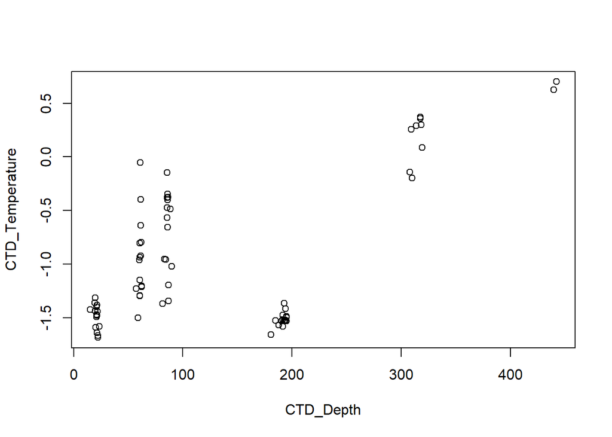

```r
with(bg_chem, plot(CTD_Depth, CTD_Temperature))
```

# Accessing and using data from a repository (archive)

Note, below, URL is assigned to a variable for later use in the script. Also, it runs better.

```r
# Read and plot data from doi:10.18739/A25T3FZ8X
#bg_chem_url <- "https://arcticdata.io/metacat/d1/mn/v2/object/urn%3Auuid%3A35ad7624-b159-4e29-a700-0c0770419941"
#bg_chem = read.csv(bg_chem_url, stringsAsFactors = FALSE)
#plot(bg_chem$CTD_Depth, bg_chem$CTD_Temperature)
```

# Using a DOI instead of the URL to access data

where the data (just like a published paper) has a doi. Doi is more stable than using URL. The data may be moved from one archive to another (URL no longer works) but will retain the doi for that version of the data used for analysis. This is reason for using this doi approach instead of typing the URL into the script.

```r
library(dataone)
library(datapack)
```

One way to connect to a data repository is using ‘D1Client’ a proxy for a repository, 2 argument, which data from the PROD, production, environment for access to datawhich repository

```r
client <- D1Client("PROD", "urn:node:KNB")
```

and then we use that client object to access the entire ’DataPackage“, which includes both the data from all of the data from all of the data files as well as the metadata that describes the data.

```r
doi <- "doi:10.5063/F1Z036CP"
client <- D1Client("PROD", "urn:node:KNB")
pkg <- getDataPackage(client, doi)
```

Grabbing the data for the csv file from that package:

```r
getIdentifiers(pkg)
```

```
## [1] "doi:10.5063/F1Z036CP"
## [2] "urn:uuid:28459949-41ce-43b8-b75f-350cc85ff775"
## [3] "urn:uuid:ac19c189-8437-4694-bcb8-93f33047ced5"
```

```r
do <- getMember(pkg, getIdentifiers(pkg)[3])
csvtext <- rawToChar(getData(do))
dframe <- read.csv(textConnection(csvtext), stringsAsFactors = FALSE)
head(dframe)
```

```
##    ï..Date Year         Area                                   Meeting
## 1  1/10/17 2017       Kodiak                            Kodiak Finfish
## 2 11/30/16 2016   Cook Inlet                  Lower Cook Inlet Finfish
## 3 11/30/16 2016   Cook Inlet                  Lower Cook Inlet Finfish
## 4  12/3/14 2014 Copper River              Prince William Sound Finfish
## 5  3/19/13 2013    Statewide Statewide Finfish and Supplemental Issues
## 6  3/19/13 2013    Statewide Statewide Finfish and Supplemental Issues
##                                 Species      Sector Proposal..
## 1                             Salmonids  Commercial         52
## 2                             Salmonids  Sport Fish         22
## 3                             Salmonids  Sport Fish         23
## 4                             Salmonids Subsistence         37
## 5 Salmonids, Groundfish, Herring, Other  Commercial        222
## 6                             Salmonids  Commercial        223
##                  Statute_Num
```

[output cut: 48 more lines]

We can also use R for uploading data to the repository, but it is more efficient to use the online submission tool (metadata required) to do this for one file, unless, this file is updated every other time with new data.

# FUNCTIONS

What are function and why do we use them?

**Code should be DRY - Don’t repeat yourself!**

Everytime you repear something, think about creating a function, it’s also a good way to organize your code.

Functions are just like variables or objects in R and you need to define them. Use keyword function to define the function and the braces show what the function does, the bloakc of code being executed. In the case below, we have one argument.

```r
x<- 2
x+2
```

```
## [1] 4
```

```r
plustwo <- function(x) {return (x+2)}
#examples of use
plustwo(4)
```

```
## [1] 6
```

```r
plustwo(8)
```

```
## [1] 10
```

Airtemperature conversion example

- how not to do it

```r
airtemps <- c(212,30.3, 78, 32)
celsius1 <- (airtemps[1]-32)*5/9
celsius2 <- (airtemps[2]-32)*5/9
```

- how to do it with a function

```r
FtoC <- function(fahr) {
  celsius <- (fahr-32)*5/9
  return(celsius)
}
```

In mathematics, this is a function: y = 2x+3 In computer science, y is the return value and 2x+3 is the function in computer science we could code y = line(4)

```r
line <- function(x) {
  y = 2*x +3
  return(y)
}
line(4)
```

```
## [1] 11
```

If you have functions you want to use in different files such as Rmd files, then you save the function in a separate file and call it from within the code. You can also create a package yourself and call that. The former uses “source” and the latter uses “library”

Make sure to create an R-script and never use an Rmd file as the file that defines the function.

Let’s do nested functions y = 2x+3 x = add constant(z) y = line(add constant(5)) line “of” add constant “of” 5 the result of one function is returned and used in the outer function

executing a function is calling a function each time you execute a function from the inside out, the entire nested block is called a “call stack” returning up the stack, the lowest call is the one first executed

## 9. GIT and GIThub

“commit” use this to push your git repository ot Github into the cloud “branch and”merge" are more advanced topic in verison control “tags” are used as bookmarks in your code These are useful for showing what code/model was used to get a certain published result.

*when to commit* Plan development steps, then commit after each step is completed.

*working with git* you are only seeing the current version,

- **add** the files you want to save to the staging
- then those files are committed to the local repository
- push the local repository to the remote respository

hidden folders, never go in there, they start with a dot .

To create a repository go to Git Hub, press upper RH plus sign to add repository, make sure to click initialize at the bottom and choose R below in the gitignore

*Working with git collaboratively:*

- 1. pull to get the latest versions
- 2. work
- 3. pull ( before you commit to avoid conflicts with changes others have made)
- 4. commit the changes to the local repository
- 5. push to the remote repository

## 10. Data Modeling and Tidy Data

The most useful and frequently join is the *left join*, where the left hand table needs information for its records from a right hand table, only importing information from the right that is a match to left. So you take a subset on the right, the records that match the left table. Note, right and left joins do *the same thing*, and depend on what table is coded first. So we could just use the left join. *inner join* subset the records for which there is information on the left and right tables. *full join* takes all records from left and right regardless of mathing information.

## 11. Data cleaning and manipulation

Tidy data is usually long format Good reasons for wide format (years in column for example) easy for data entry, presentations, quick look at trends, etc. but when making calculations, it’s really hard to do in the wide format.

*switching from wide to tall (long) format using tidyr*

In this lesson we’re going to walk through the functions you’ll most commonly use from the dplyr and tidyr packages:

dplyr

- mutate()
- group_by()
- summarise()
- select()
- filter()
- arrange()
- left_join()
- rename() tidyr
- gather()
- spread()
- extract()
- separate()

The dplyr and tidyr have conflicts in function names associated with basic R stats package related to filter and lag. You can avoide this by using two colons PackageName::FunctionName

Reading in the data from [Mike Byerly. 2016. Alaska commercial salmon catches by management region (1886- 1997). Gulf of Alaska Data Portal. df35b.304.2](https://knb.ecoinformatics.org/#view/df35b.304.2)

**IMPORTANT reading in csv that works across windows and mac OS** read.csv(url(“https://knb.ecoinformatics.org/knb/d1/mn/v2/object/df35b.302.1”, method = “libcurl”),stringsAsFactors = FALSE)

```r
library(dplyr)
library(tidyr)
catch_df <- read.csv(url("https://knb.ecoinformatics.org/knb/d1/mn/v2/object/df35b.302.1", method = "libcurl"),stringsAsFactors = FALSE)
head(catch_df)
```

```
##   Region Year Chinook Sockeye Coho Pink Chum All notesRegCode
## 1    SSE 1886       0       5    0    0    0   5
## 2    SSE 1887       0     155    0    0    0 155
## 3    SSE 1888       0     224   16    0    0 240
## 4    SSE 1889       0     182   11   92    0 285
## 5    SSE 1890       0     251   42    0    0 292
## 6    SSE 1891       0     274   24    0    0 298
```